# Exam 3 Jared Nilson

# Tasks:

**1. Load and clean FacultySalaries_1995.csv file and Re-create the graph below…**

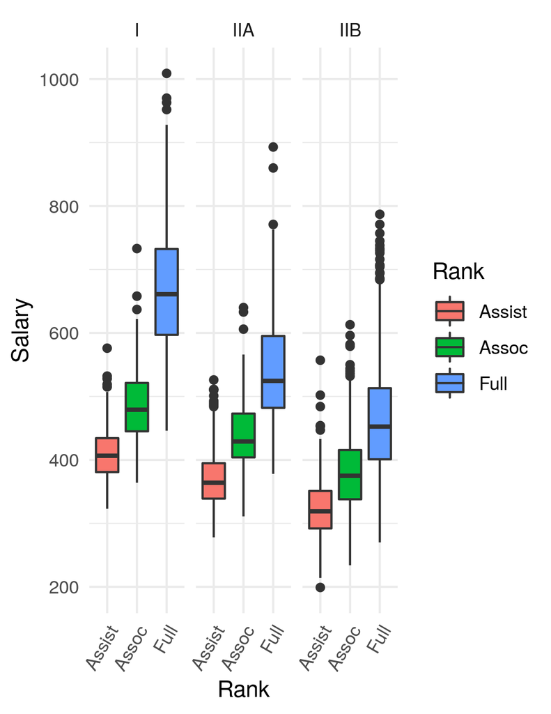

# Loading R programs

```r
library(readr)
library(tidyverse)
library(janitor)
library(easystats)
library(ggplot2)
library(broom)
```

# Reading in the data

```r
df <- read_csv("FacultySalaries_1995.csv")
```

After looking at the data and the graph that we are supposed to produce I decide that I’ll need new column with the college rank of “assoc” “assist” or “full” and then facet wrap by tier(exluding VIIB) where x is the new column and y is the salaries for each one so I need to make a new salary column as well.

```r
salary <- df %>%
  select(ends_with(c("Salary","ID","Name","State","Tier")))
salary <- salary %>%
  pivot_longer(c(AvgFullProfSalary,AvgAssocProfSalary,AvgAssistProfSalary),
               names_to = "Rank",values_to = "Salary")%>%
  mutate(Rank = Rank %>% str_remove("ProfSalary"))%>%
  mutate(Rank = Rank %>% str_remove("Avg"))
```

Lets take a look to see if it worked

```r
salary
```

```
## # A tibble: 3,483 × 6
##    FedID UnivName                  State Tier  Rank   Salary
##    <dbl> <chr>                     <chr> <chr> <chr>   <dbl>
##  1  1061 Alaska Pacific University AK    IIB   Full      454
##  2  1061 Alaska Pacific University AK    IIB   Assoc     382
##  3  1061 Alaska Pacific University AK    IIB   Assist    362
##  4  1063 Univ.Alaska-Fairbanks     AK    I     Full      686
##  5  1063 Univ.Alaska-Fairbanks     AK    I     Assoc     560
##  6  1063 Univ.Alaska-Fairbanks     AK    I     Assist    432
##  7  1065 Univ.Alaska-Southeast     AK    IIA   Full      533
##  8  1065 Univ.Alaska-Southeast     AK    IIA   Assoc     494
##  9  1065 Univ.Alaska-Southeast     AK    IIA   Assist    329
## 10 11462 Univ.Alaska-Anchorage     AK    IIA   Full      612
## # ℹ 3,473 more rows
```

```r
df<- df %>% full_join(salary)
```

To get rid of tier VIIB

```r
selected_tiers <- c("I", "IIA", "IIB")
```

Then filter the data to include only those categories and plot

```r
df <- df[df$Tier %in% selected_tiers, ]
```

# First Plot

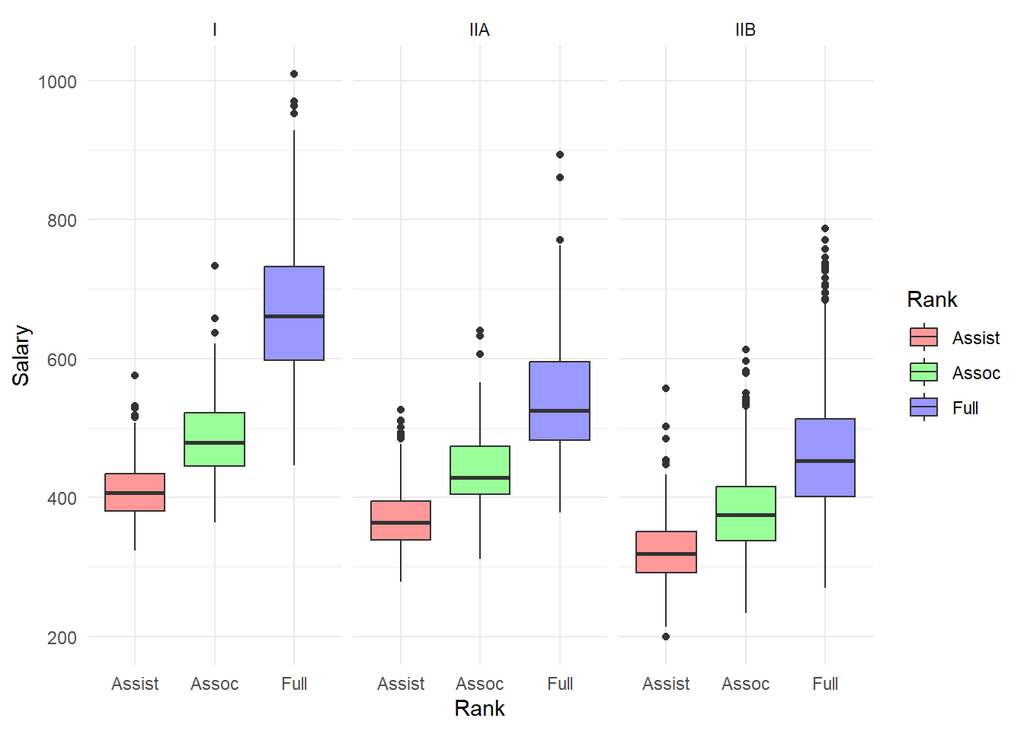

```r
x_colors <- c("#FF9999", "#99FF99", "#9999FF")
ggplot(df, aes(x=Rank,y=Salary,fill=Rank)) +
  geom_boxplot()+
  facet_wrap(~Tier)+
  scale_fill_manual(values = x_colors)+
  theme_minimal()
```

**2. Build an ANOVA model and display the summary output in your report.** To build an anova model I simply used the code below

```r
model <- aov(Salary ~ State + Rank + Tier, data = df)
# Print the ANOVA results
summary(model)
```

```
##               Df   Sum Sq Mean Sq F value Pr(>F)
## State         50  5667124  113342   31.17 <2e-16 ***
## Rank           2 16777001 8388501 2307.09 <2e-16 ***
## Tier           2  6821986 3410993  938.13 <2e-16 ***
## Residuals   3297 11987752    3636
## ---
## Signif. codes:  0 '***' 0.001 '**' 0.01 '*' 0.05 '.' 0.1 ' ' 1
## 128 observations deleted due to missingness
```

**3. The rest of the test uses another data set. The “Juniper_Oils.csv” data. Get it loaded and take a look. Then tidy it! (show the code used for tidying in your report)**

# Reading in the second dataset

```r
df2 <- read.csv("Juniper_Oils.csv")
```

After looking at the dataset and requested graph I figured that I need a column with each of the compounds and a column for concentration. This tidying can be performed with one **pivot_longer** then I plotted it.

```r
df2 <- df2 %>%
  pivot_longer(c("alpha.pinene","para.cymene","alpha.terpineol","cedr.9.ene","alpha.cedrene","beta.cedrene",
                 "cis.thujopsene","alpha.himachalene","beta.chamigrene","cuparene","compound.1","alpha.chamigrene",
                 "widdrol","cedrol","beta.acorenol","alpha.acorenol","gamma.eudesmol","beta.eudesmol","alpha.eudesmol",
                 "cedr.8.en.13.ol","cedr.8.en.15.ol","compound.2","thujopsenal"),
               names_to = "Chemical_Name", values_to = "Concentration")
```

**4. Make me a graph of the following:**

```
    x = YearsSinceBurn
    y = Concentration
    facet = ChemicalID (use free y-axis scales)
```

# Second Plot

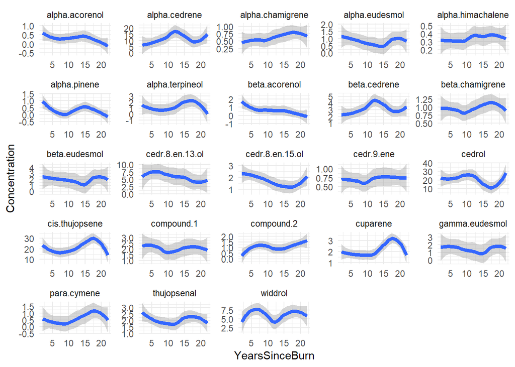

```r
ggplot(df2, aes(x=YearsSinceBurn, y=Concentration))+
  geom_smooth(size= 1.75)+
  theme_minimal()+
  facet_wrap(~Chemical_Name, scales = "free")
```

**5. Use a generalized linear model to find which chemicals show concentrations that are significantly (significant, as in P < 0.05) affected by “Years Since Burn”.**

```r
model <- glm(formula = Concentration ~ YearsSinceBurn + Chemical_Name, data = df2, family = gaussian)

# Extract and tidy the model coefficients
tidy_results <- tidy(model)

# Filter for significant results (p-value < 0.05)
significant_results <- tidy_results[tidy_results$p.value < 0.05, ]
significant_results
```

```
## # A tibble: 10 × 5
##    term                         estimate std.error statistic  p.value
##    <chr>                           <dbl>     <dbl>     <dbl>    <dbl>
##  1 Chemical_Namealpha.cedrene      10.6      0.899     11.8  1.13e-29
##  2 Chemical_Namebeta.cedrene        2.78     0.899      3.09 2.09e- 3
##  3 Chemical_Namebeta.eudesmol       1.79     0.899      1.99 4.71e- 2
##  4 Chemical_Namecedr.8.en.13.ol     5.55     0.899      6.17 1.08e- 9
##  5 Chemical_Namecedrol             19.8      0.899     22.0  1.40e-83
##  6 Chemical_Namecis.thujopsene     21.3      0.899     23.7  3.09e-93
##  7 Chemical_Namecompound.1          1.82     0.899      2.02 4.36e- 2
##  8 Chemical_Namecuparene            1.92     0.899      2.14 3.28e- 2
##  9 Chemical_Namethujopsenal         1.79     0.899      1.99 4.71e- 2
## 10 Chemical_Namewiddrol             6.14     0.899      6.82 1.84e-11
```

The “Chemical_Name” in front is ugly obviously so I got rid of that and we have our final dataframe.

```r
df3 <- significant_results %>% mutate(term = term %>% str_remove("Chemical_Name"))
# Print the significant results
print(df3)
```

```
## # A tibble: 10 × 5
##    term            estimate std.error statistic  p.value
##    <chr>              <dbl>     <dbl>     <dbl>    <dbl>
##  1 alpha.cedrene      10.6      0.899     11.8  1.13e-29
##  2 beta.cedrene        2.78     0.899      3.09 2.09e- 3
##  3 beta.eudesmol       1.79     0.899      1.99 4.71e- 2
##  4 cedr.8.en.13.ol     5.55     0.899      6.17 1.08e- 9
##  5 cedrol             19.8      0.899     22.0  1.40e-83
##  6 cis.thujopsene     21.3      0.899     23.7  3.09e-93
##  7 compound.1          1.82     0.899      2.02 4.36e- 2
##  8 cuparene            1.92     0.899      2.14 3.28e- 2
##  9 thujopsenal         1.79     0.899      1.99 4.71e- 2
## 10 widdrol             6.14     0.899      6.82 1.84e-11
```